# Historia y objetivos de la salud pública

## Introducción

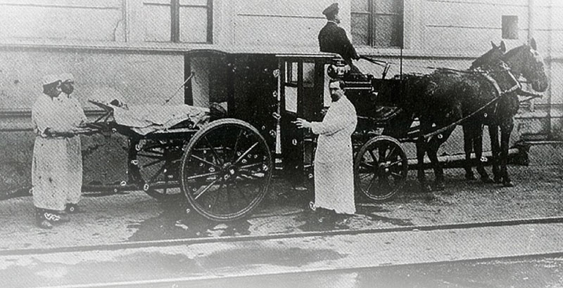

Fuente: insitulogistica.com.ar

Se puede decir que el sistema de salud pública de Buenos Aires empezó a tomar forma de un modo decidido con ocasión de la epidemia de fiebre amarilla que hubo en 1871. [Aquí](https://www.youtube.com/watch?v=ZrFqVJT6EVw) puedes escuchar como fue esta epidemia.

## Actividad 1

A partir del video o de otra fuente de información **copia** y **completa** el siguiente texto reemplazando cada línea “______” por una sola palabra correcta. Si aparece una letra en medio de la línea significa que va una palabra que empieza con esa letra. Por ejemplo la primera es “*a*” y va “amarilla”.

*La epidemia de fiebre *a* que azotó Buenos Aires en 1871 fue una de las más devastadoras de la historia argentina, con alrededor de 14.000 muertos, especialmente en los barrios del *s*. Comenzó en enero y se ______ rápidamente debido a las malas condiciones sanitarias, el hacinamiento y la falta de sistemas de alcantarillado. La ciudad quedó paralizada y muchas autoridades abandonaron sus cargos. En medio del caos, se ______ la labor del médico Guillermo Rawson, quien impulsó medidas sanitarias y sentó las *b* de la salud pública en el país. También fue crucial la acción de la recientemente creada Sociedad de Beneficencia y de voluntarios civiles como los “Caminantes de la Salud”. La tragedia marcó un punto de inflexión en la *o* sanitaria de Buenos Aires.*

## Desarrollo histórico de la salud pública y comunitaria en Argentina

### Etapas clave:

**a. Siglo XIX – Higienismo:**

- Primeras medidas sanitarias (control de epidemias, cuarentenas, vacunación).
- Creación del Departamento Nacional de Higiene (1880).
- Enfoque centrado en el control de enfermedades transmisibles como la fiebre amarilla, el cólera, la viruela, la tuberculosis, la fiebre tifoidea, tifus, etc.

**b. Siglo XX – Salud pública moderna:**

- Se organiza el sistema de salud: hospitales públicos, obras sociales, sanatorios privados.
- Se desarrollan campañas de vacunación, control de tuberculosis, lepra, chagas.
- **Ramón Carrillo (ministro de Salud de Perón en 1946)**: impulsó hospitales, atención primaria, medicina preventiva, salud mental.

**c. Décadas recientes – Salud comunitaria:**

- Esta etapa se enfoca en las necesidades específicas de una comunidad (un barrio, una localidad, un grupo social). Implica el trabajo cercano con la población, la participación activa de vecinos, agentes sanitarios, organizaciones barriales, y el diseño de acciones adaptadas a su realidad concreta.

## Actividad 2

Buscá y escribe quién fue Ramón Carrillo y qué aportes hizo a la salud pública en Argentina.

## Actividad 3: Objetivos de la salud pública y comunitaria

Los objetivos de la salud pública son de sentido común. Están nombrados abajo pero en forma incompleta para que tu los copies completado con la palabra que falta:

**Objetivos:**

- Prevenir ______.
- Promover la ______.
- Mejorar la ______ de vida.
- Reducir desigualdades en salud.

## Actividad 4:

**1)** En la etapa **a)** del **Higienismo** se nombran una serie de enfermedades que si bien están más controladas, aun existen. Elige una de estas enfermedades, alguna que te despierte curiosidad, investiga y escribe un texto de unos 5 renglones describiendo la enfermedad y los modos de evitarla.

**2)** ¿En tu comunidad hay políticas de prevención de enfermedades? ¿Cuáles? ¿Qué barreras existen para acceder a una buena atención médica?